# Moodle Tasks

б)$X \in Unif(1, 5)$

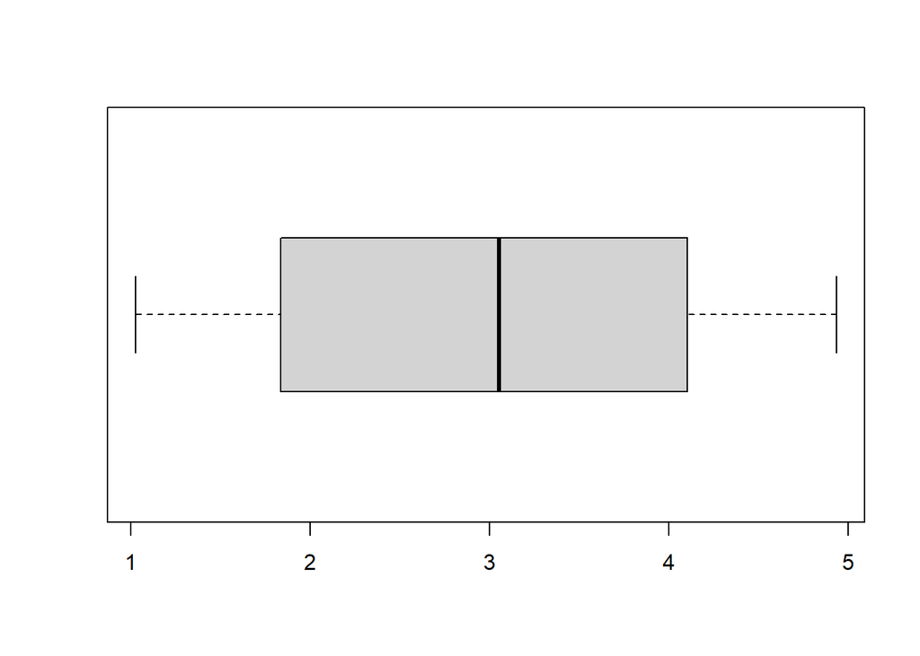

```r
> x <- runif(100, min = 1, max = 5)
> boxplot(x, horizontal = TRUE)
```

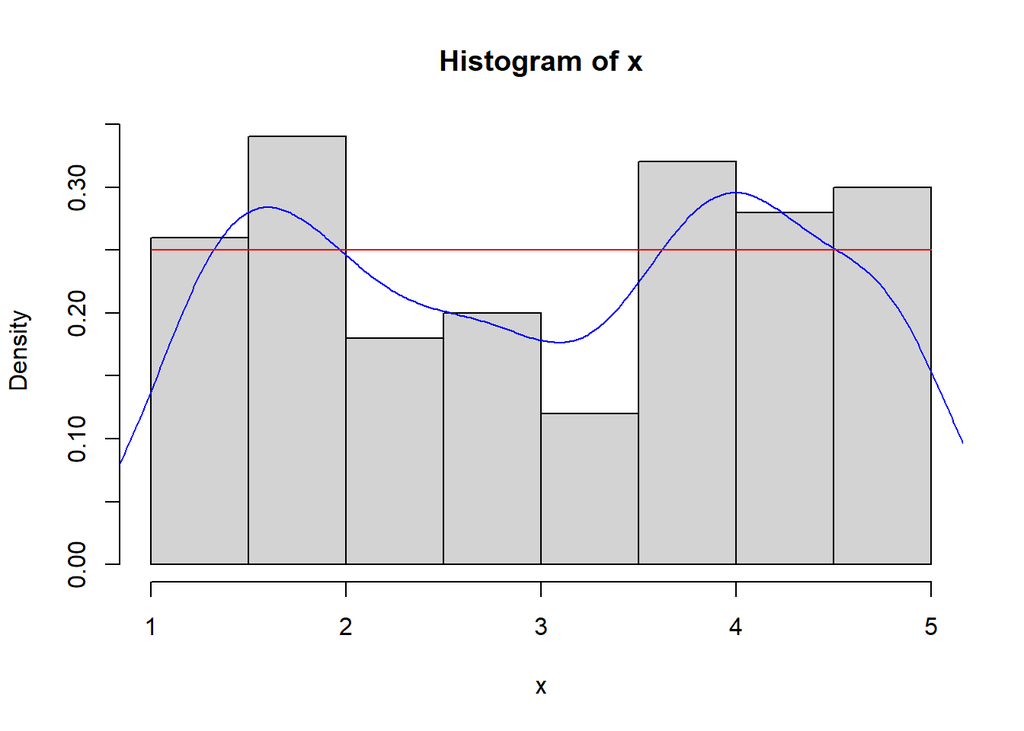

```r
> hist(x, probability = TRUE)
> lines(density(x, bw = "SJ"), col = "blue")
> curve(dunif(x, min = 1, max = 5), add = TRUE, col = "red")
```

```r
> skewness(x)
[1] -0.03823542
```

Коефициентът на асиметрия на равномерното разпределение е $0$. Коефициентът на асиметрия в извадката е приблизително $0$, т.е. разпределението е симетрично. Т.к. точното разпределение на емперичния коефициент на асметрия в случая не е известно, смисълът на думата приблизително можем да го анализираме само при големи извадки.

```r
> kurtosis(x)
[1] -1.397541
```

в) $X \in Exp(3)$

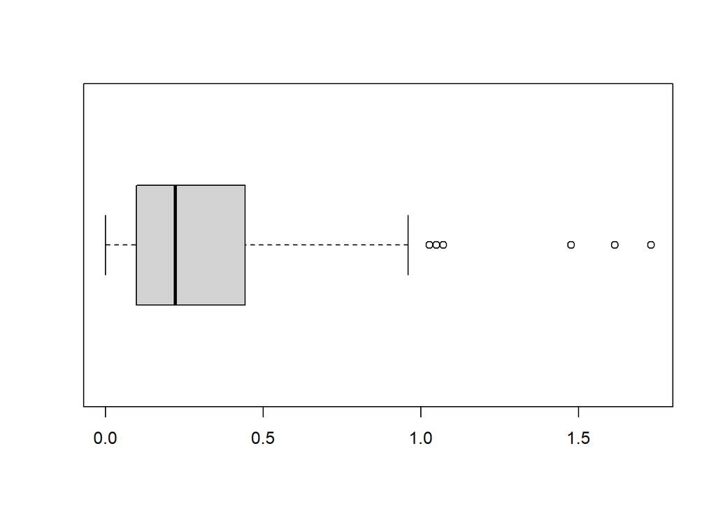

```r
> x <- rexp(100, rate = 3)
> boxplot(x, horizontal = TRUE)
```

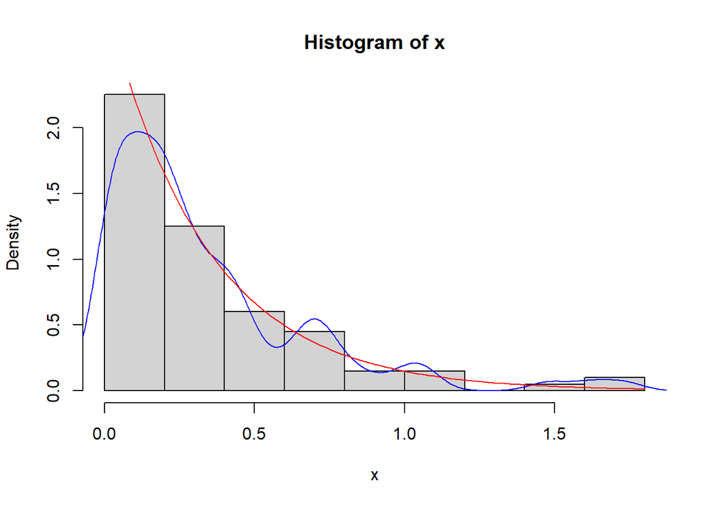

```r
> hist(x, probability = TRUE)
> lines(density(x, bw = "SJ"), col = "blue")
> curve(dexp(x, rate = 3), add = TRUE, col = "red")
```

```r
> skewness(x)
[1] 1.871814
```

Коефициентът на асиметрия на експоненциалното разпределение е $2$. За това получените коефициенти в случая ще бъдат положитени приблизително $2$, т.е. имаме разпределение с дясна асиметрия. Т.к. точното разпределение на емперичния коефициент на асметрия в случая не е известно, смисълът на думата приблизително можем да го анализираме само при големи извадки.

```r
> kurtosis(x)
[1] 4.07156
```

Коефициентът на изостреност /ексцес/ на експоненциалното разпределение е положителен $6$. Коефициентът на изостреност /ексцес/ в извадката ще е също положителен приблизително $6$, т.е. имаме leptokurtic разпределение (наднормален ексцес).

Разпределението ни е едномодално.

г) $X \in Gamma(\alpha = 5, \beta = 1)$
$$\theta = \frac{1}{\beta} = 1$$

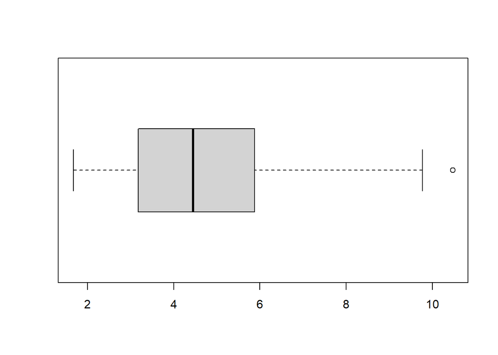

```r
> x <- rgamma(100, shape = 5, rate = 1)
> boxplot(x, horizontal = TRUE)
```

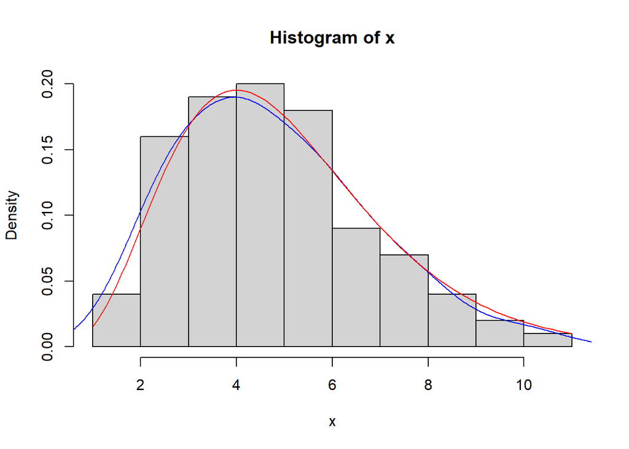

```r
> hist(x, probability = TRUE)
> lines(density(x, bw = "SJ"), col = "blue")
> curve(dgamma(x, shape = 5, rate = 1), add = TRUE, col = "red")
```

```r
> skewness(x)
[1] 0.6579746
```

Коефициентът на асиметрия на гама разпределението зависи от параметъра $\alpha$ и е $\frac{2}{\sqrt{\alpha}} = \frac{2}{\sqrt{5}} \approx 0.89$. За това получените коефициенти в случая ще бъдат приблизително $0.89$, т.е. имаме разпределение с дясна асиметрия. Т.к. точното разпределение на емперичния коефициент на асметрия в случая не е известно, смисълът на думата приблизително можем да го анализираме само при големи извадки.

```r
> kurtosis(x)
[1] 0.0242497
```

Коефициентът на изостреност /ексцес/ на гама разпределението зависи от параметъра $\alpha$ и е $\frac{6}{\alpha} = \frac{6}{5} = 1.2$. За това получените коефициенти в случая ще бъдат приблизително $1.2$, т.е. имаме leptokurtic разпределение (наднормален ексцес).

Разпределението ни е едномодално.

д) $X \in \chi^2(3)$

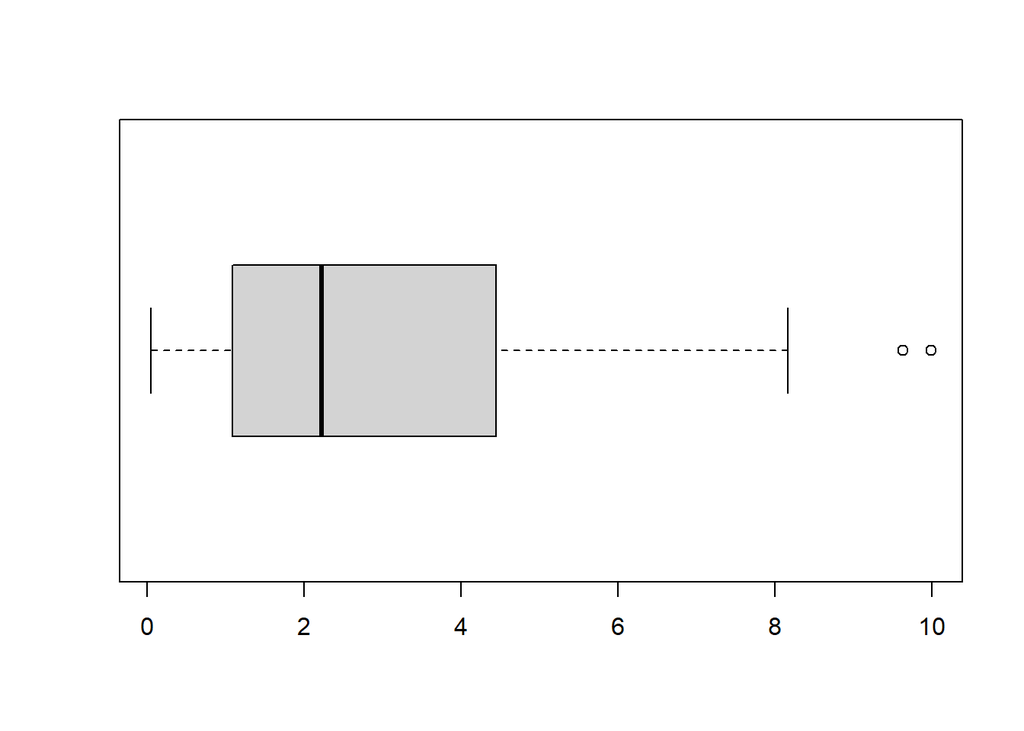

```r
> x <- rchisq(100, df = 3)
> boxplot(x, horizontal = TRUE)
```

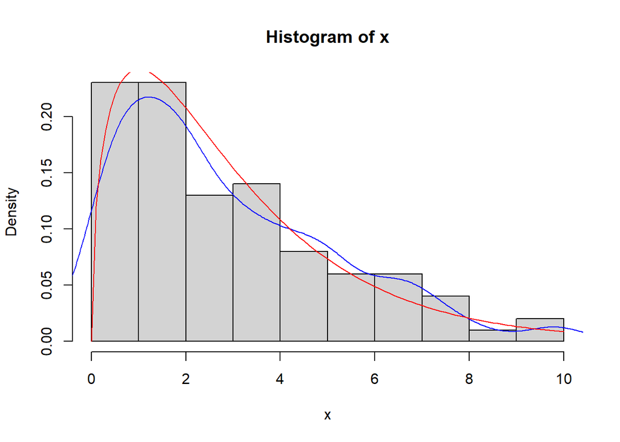

```r
> hist(x, probability = TRUE)
> lines(density(x, bw = "SJ"), col = "blue")
> curve(dchisq(x, df = 3), add = TRUE, col = "red")
```

```r
> skewness(x)
[1] 0.9812058
```

Коефициентът на асиметрия на $\chi^2$ разпределението зависи от степените на свобода $n$ и е $\sqrt{\frac{8}{n}} = \sqrt{\frac{8}{3}} \approx 1.63$. За това получените коефициенти в случая ще бъдат приблизително $1.63$, т.е. имаме разпределение с дясна асиметрия. Т.к. точното разпределение на емперичния коефициент на асметрия в случая не е известно, смисълът на думата приблизително можем да го анализираме само при големи извадки.

```r
> kurtosis(x)
[1] 0.434238
```

Коефициентът на изостреност /ексцес/ на $\chi^2$ разпределението зависи от степените на свобода $n$ и е $\frac{12}{n} = \frac{12}{3} = 4$. За това получените коефициенти в случая ще бъдат приблизително $4$, т.е. имаме leptokurtic разпределение (наднормален ексцес).

Разпределението ни е едномодално.

е) $X \in t(5)$

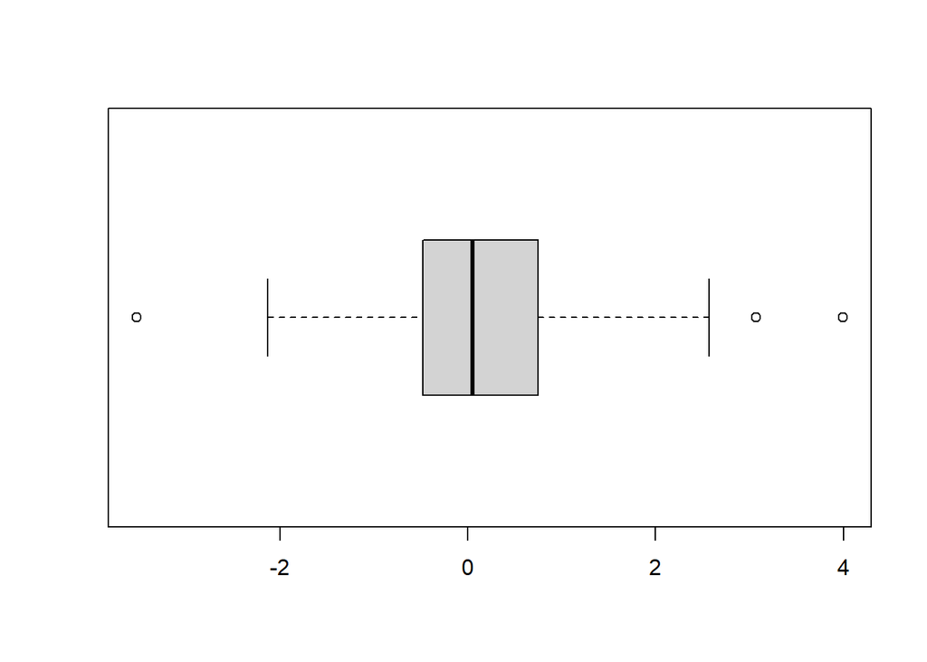

```r
> x <- rt(100, df = 5)
> boxplot(x, horizontal = TRUE)
```

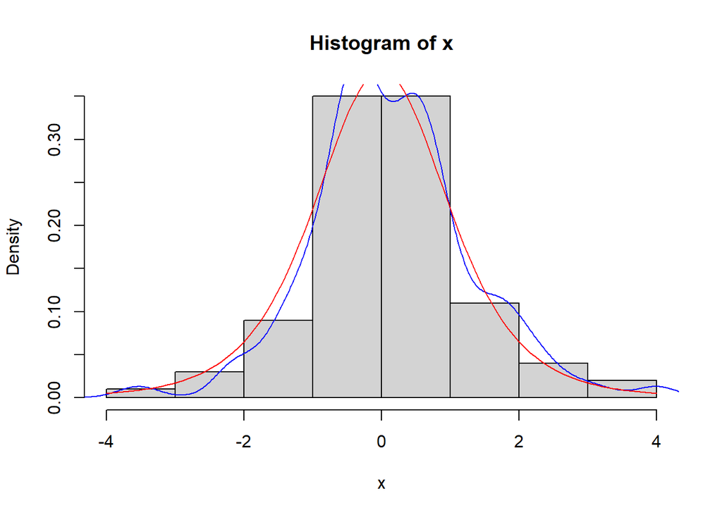

```r
> hist(x, probability = TRUE)
> lines(density(x, bw = "SJ"), col = "blue")
> curve(dt(x, df = 5), add = TRUE, col = "red")
```

```r
> skewness(x)
[1] 0.256678
```

Коефициентът на асиметрия на Student-t разпределението с повече от $3$ степени на свобода $\nu > 3$ е $0$. В противен случай той не съществува. Коефициентът на асиметрия в извадката е приблизително $0$, т.е. разпределението е симетрично. Т.к. точното разпределение на емперичния коефициент на асметрия в случая не е известно, смисълът на думата приблизително можем да го анализираме само при големи извадки.

```r
> kurtosis(x)
[1] 1.330325
```

Разпределението ни е едномодално.

ж) $X$ е смес от две разпределения $N(1, 2)$ и $N(5, 2)$ с вероятност за първото $p = 0.4$.

$$I_A \in Bernoulli(0.4)$$
$$X = I_A * N(1, 2) + I_{\bar{A}} * N(5, 2)$$

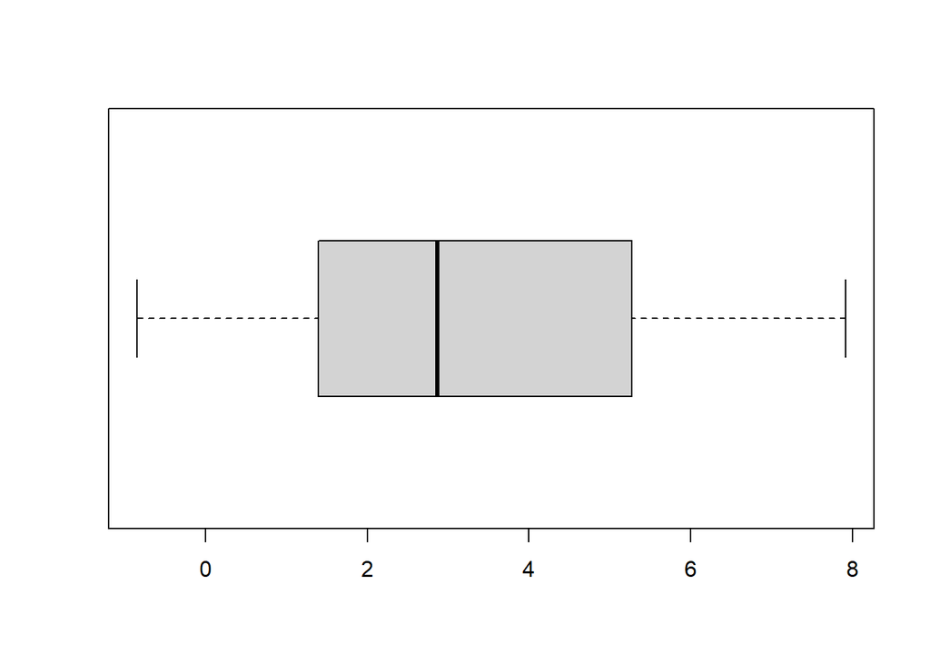

```r
> i <- rbinom(100, size = 1, prob = 0.4)
> n1 <- rnorm(100, mean = 1, sd = sqrt(2))
> n2 <- rnorm(100, mean = 5, sd = sqrt(2))
> x <- i * n1 + (1 - i) * n2
> boxplot(x, horizontal = TRUE)
```

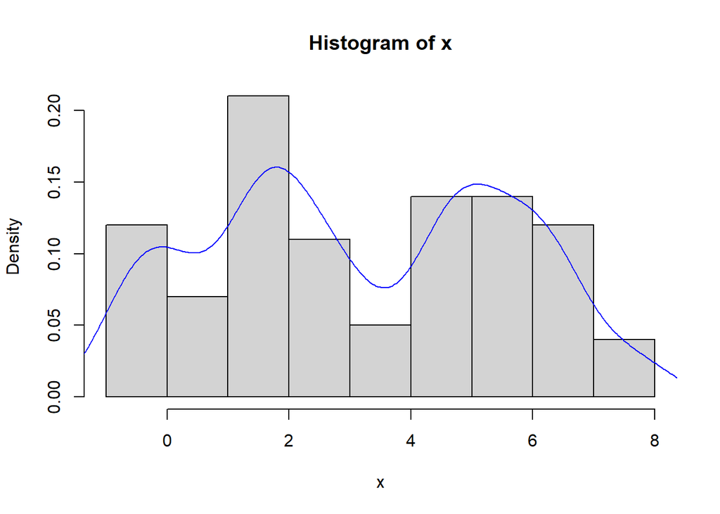

```r
> hist(x, probability = TRUE)
> lines(density(x, bw = "SJ"), col = "blue")
```

```r
> skewness(x)
[1] 0.03142663
> kurtosis(x)
[1] -1.170658
```

т.к. теоретичните стойности на коефициентите на асиметрия и ексцес в случая не са известни ще ги определим само емпирично.

Коефициентът на асиметрия в извадката е приблизително $0$, т.е. имаме почти симетрично емпирично разпределение.

Коефициентът на изостреност /ексцес/ е отрицателен, т.е. имаме platykurtic емпирично разпределение (поднормален ексцес).

Разпределението ни е двумодално.

з) $X$ е смес от три разпределения $N(1, 2)$, $N(10, 2)$ и $N(-3, 2)$ с вероятности съответно $p_1 = 0.3$, $p_2 = 0.2$ и $p_3 = 0.5$.

Полиномно разпределение
$$(I_1, I_2, I_3) \in Multinomial(1;\ p_1,\ p_2,\ p_3), \quad p_1 + p_2 + p_3 = 1$$
$$X = I_1 * N(1, 2) + I_2 * N(10, 2) + I_3 * N(-3, 2)$$

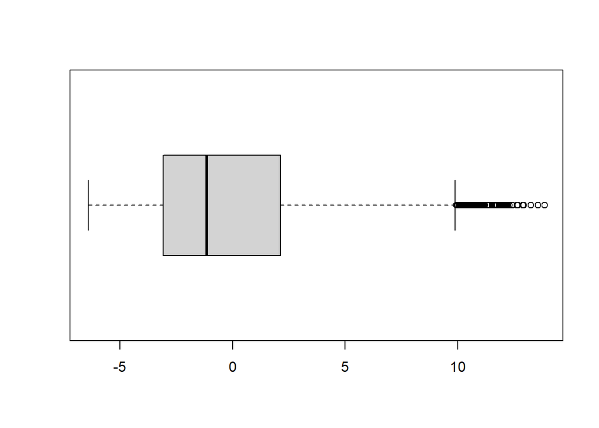

```r
> u <- runif(1000)
> head(u)
[1] 0.8978525 0.6388236 0.8983280 0.9250399 0.6319482 0.4934617
> p1 <- 0.3
> p2 <- 0.2
> p3 <- 0.5
> i1 <- u < p1
> head(i1)
[1] FALSE FALSE FALSE FALSE FALSE FALSE
> i2 <- u > p1 & u < p2+p1
> head(i2)
[1] FALSE FALSE FALSE FALSE FALSE  TRUE
> i3 <- u > p1+p2
> head(i3)
[1]  TRUE  TRUE  TRUE  TRUE  TRUE FALSE
> n1 <- rnorm(1000, mean = 1, sd = sqrt(2))
> n2 <- rnorm(1000, mean = 10, sd = sqrt(2))
> n3 <- rnorm(1000, mean = -3, sd = sqrt(2))
>
> x <- i1 * n1 + i2 * n2 + i3 * n3
> boxplot(x, horizontal = TRUE)
```

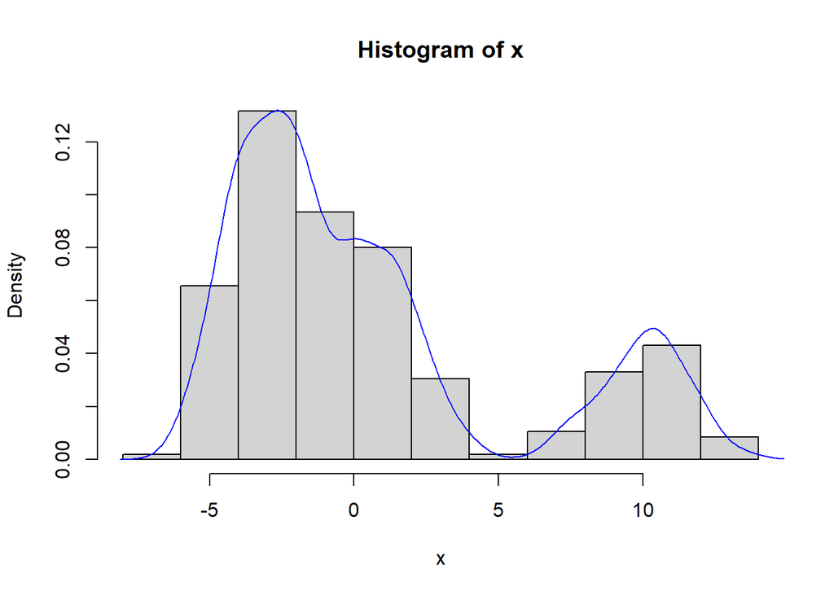

```r
> hist(x, probability = TRUE)
> lines(density(x, bw = "SJ"), col = "blue")
```

```r
> skewness(x)
[1] 1.045699
> kurtosis(x)
[1] -0.1233133
```

## Задача 2

Нека $X_1, X_2, ..., X_n$ са независими сл.в. зададени както в Зад.1. Какво можете да кажете за разпределението на $Y = X_1 + X_2 + ... + X_n$. Разгледайте случаите $n = 2, \: 10, \: 100$.

### Решение:

а) $X_1, X_2, ..., X_n \in N(5, 2)$

От $X_i \in N(\mu_i, \sigma_i^2)$ и $X_i$ независими за $i = 1, ..., n$, то
$$X_1 + X_2 + ... + X_n \in N(\mu_1 + \mu_2 + ... + \mu_n, \sigma_1^2 + \sigma_2^2 + ... + \sigma_n^2)$$
В нашия случай
$$Y = X_1 + X_2 + ... + X_n \in N(5n, 2n)$$
При $n = 2$
$$Y = X_1 + X_2 \in N(10, 4)$$

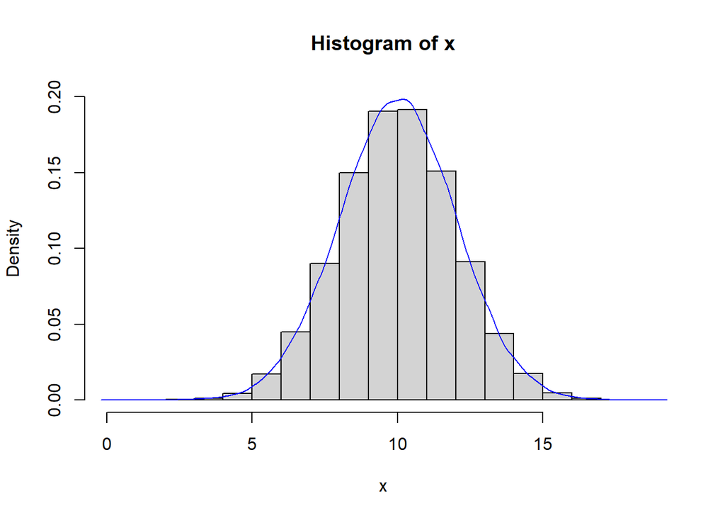

```r
> n <- 2
> x <- rnorm(10^5, mean = 5*n, sd = sqrt(2*n))
> hist(x, probability = TRUE, ylim = c(0, 0.2))
> lines(density(x, bw = "SJ"), col = "blue")
```

При $n = 10$
$$Y = X_1 + X_2 + ... + X_{10} \in N(50, 20)$$

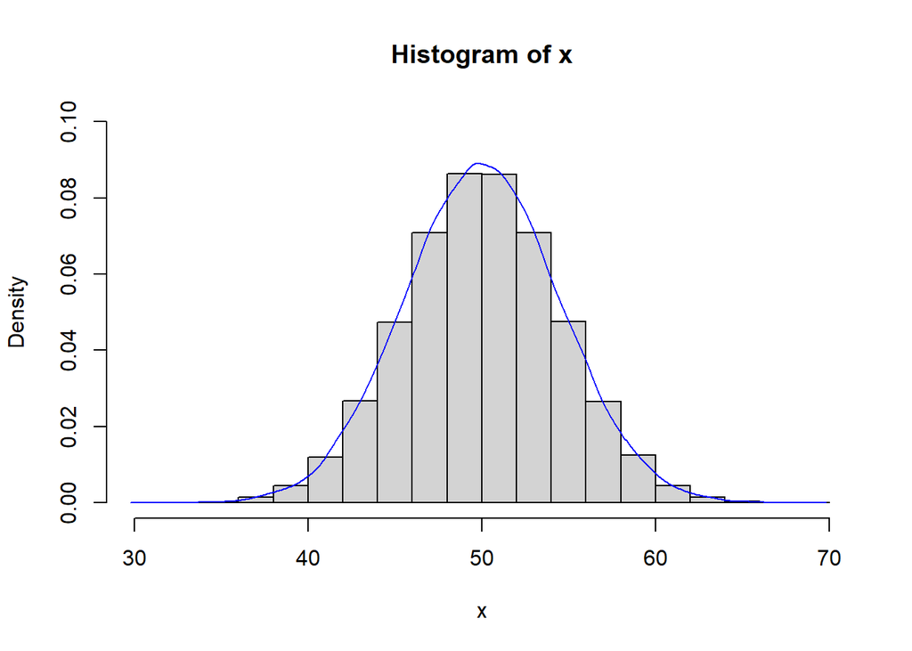

```r
> n <- 10
> x <- rnorm(10^5, mean = 5*n, sd = sqrt(2*n))
> hist(x, probability = TRUE, ylim = c(0, 0.1))
> lines(density(x, bw = "SJ"), col = "blue")
```

При $n = 100$
$$Y = X_1 + X_2 + ... + X_{100} \in N(500, 200)$$

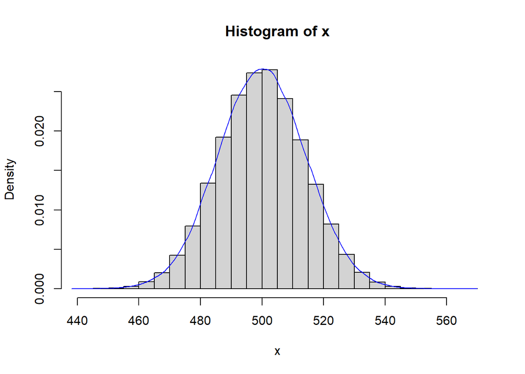

```r
> n <- 100
> x <- rnorm(10^5, mean = 5*n, sd = sqrt(2*n))
> hist(x, probability = TRUE)
> lines(density(x, bw = "SJ"), col = "blue")
```

б) $X_1, X_2, ..., X_n \in Unif(1, 5)$

$$E[X_1 + X_2 + \ldots + X_n] = nE[X_1] = n \frac{1 + 5}{2} = 3n$$

$$D[X_1 + X_2 + \ldots + X_n] = nD[X_1] = n \frac{(5 - 1)^2}{12} = \frac{4}{3}n$$

При $n = 2$
$$Y = X_1 + X_2$$
$$E[X_1 + X_2] = 2 E[X_1] = 2 * 3 = 6$$
$$D[X_1 + X_2] = 2 D[X_1] = 2 \frac{4}{3} = \frac{8}{3} \approx 2.67$$

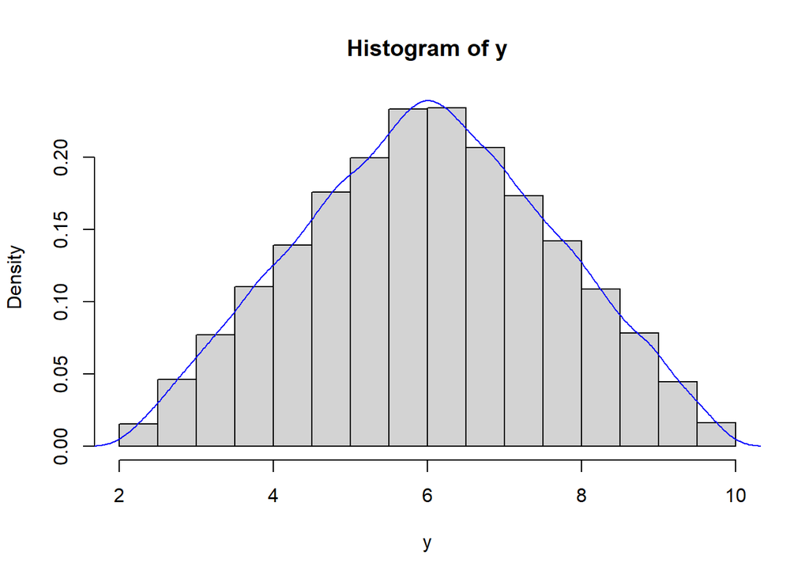

```r
> x1 <- runif(50000, min = 1, max = 5)
> x2 <- runif(50000, min = 1, max = 5)
> y <- x1 + x2
> mean(y)
[1] 6.003515
> var(y)
[1] 2.661459
> hist(y, probability = TRUE)
> lines(density(y, bw = "SJ"), col = "blue")
```

При $n = 10$
$$Y = X_1 + X_2 + \ldots + X_{10}$$
$$E[X_1 + X_2 + \ldots + X_{10}] = 10 E[X_1] = 10 * 3 = 30$$
$$D[X_1 + X_2 + \ldots + X_{10}] = 10 D[X_1] = 10 \frac{4}{3} = \frac{40}{3} \approx 13.33$$

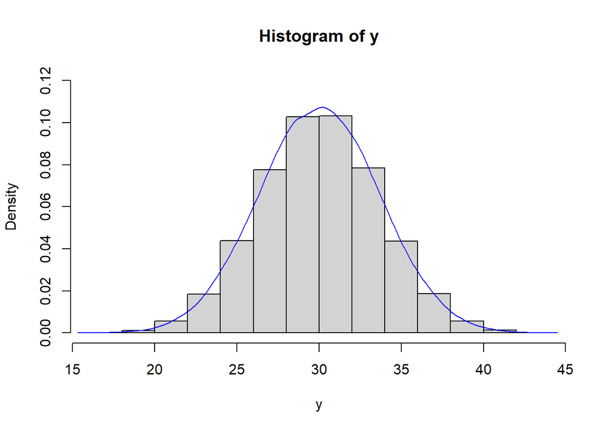

```r
> y <- 0
> for(i in 1:(10^5)){
+   y[i] <- sum(runif(10, min = 1, max = 5))
+ }
> mean(y)
[1] 30.0088
> var(y)
[1] 13.28398
> hist(y, probability = TRUE, ylim = c(0, 0.12))
> lines(density(y, bw = "SJ"), col = "blue")
```

При $n = 100$
$$Y = X_1 + X_2 + \ldots + X_{100}$$
$$E[X_1 + X_2 + \ldots + X_{100}] = 100 E[X_1] = 100 * 3 = 300$$
$$D[X_1 + X_2 + \ldots + X_{100}] = 100 D[X_1] = 100 \frac{4}{3} = \frac{400}{3} \approx 133.33$$

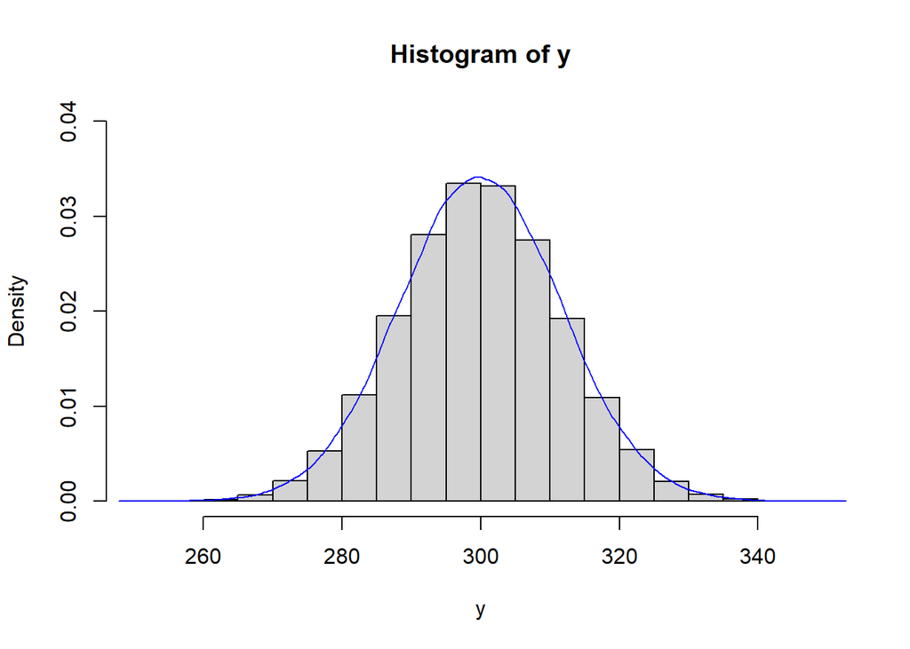

```r
> y <- 0
> for(i in 1:(10^5)){
+   y[i] <- sum(runif(100, min = 1, max = 5))
+ }
> mean(y)
[1] 299.9539
> var(y)
[1] 134.0964
> hist(y, probability = TRUE, ylim = c(0, 0.04))
> lines(density(y, bw = "SJ"), col = "blue")
```

т.к. $100$ е голямо можем да използваме централна гранична теорема (ЦГТ).

От централна гранична теорема (ЦГТ), ако $X_i$ еднакво разпределени, независими и с **крайна дисперсия** за $i = 1, ..., n$, то при увеличаване на обема на извадката
$$\frac{X_1 + X_2 + ... + X_n - n E[X]}{\sqrt{n D[X]}} \mathop{\to}^d N(0, 1)$$
В случая
$$E[X_i] = \frac{a+b}{2} = \frac{1 + 5}{2} = 3$$
$$D[X_i] = \frac{(b-a)^2}{12} = \frac{(5-1)^2}{12} = \frac{4}{3}$$
$$Y = X_1 + X_2 + ... + X_n$$
$$\frac{Y - n E[X]}{\sqrt{n D[X]}} \mathop{\to}^d N(0, 1)$$
$$\frac{Y - 3n}{\sqrt{\frac{4}{3}n}} \mathop{\to}^d N(0, 1)$$

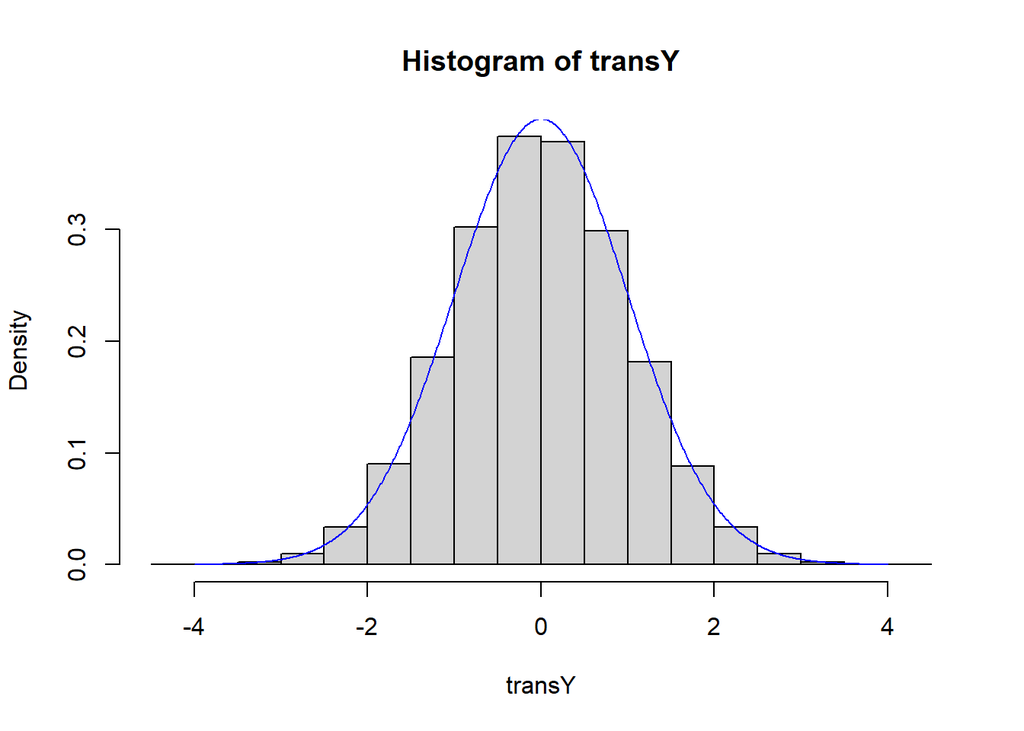

```r
> transY <- (y - 3*n) / sqrt((4*n)/3)
> hist(transY, probability = TRUE)
> xCoord <- seq(-4, 4, 0.01)
> lines(xCoord, dnorm(xCoord, 0, 1), col = "blue")
```

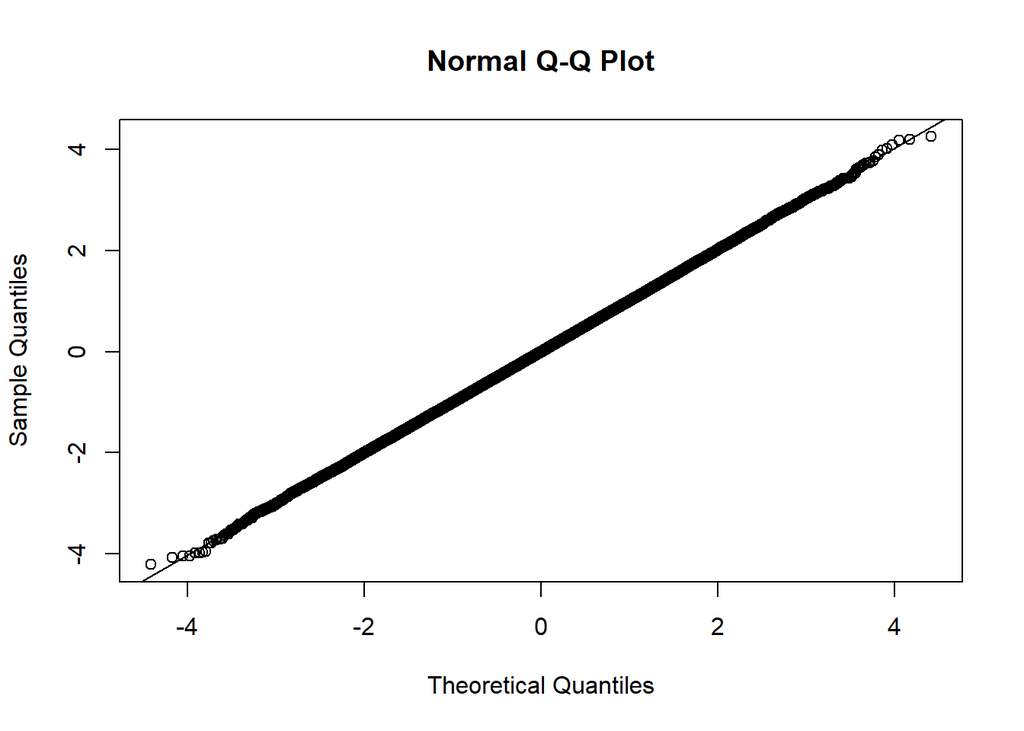

```r
> qqnorm(transY)
> qqline(transY)
```

в) $X_1, X_2, ..., X_n \in Ex(3)$

Тъй като $Ex(\lambda) \equiv \Gamma(1,\lambda)$ и сума на независими гама случайни величини с един и същ втори параметър е отново гама със същия втори параметър, а първите параметри се сумират, то

$$Y = X_1 + X_2 + ... + X_n \in \Gamma(n, 3)$$

$$f_Y(x) = \frac{3^n}{\Gamma(n)}x^{n-1}e^{-3x} = \frac{3^n}{(n-1)!}x^{n-1}e^{-3x}, \quad x > 0$$
$$E[X_1 + X_2 + \ldots + X_n] = \frac{n}{3}$$

$$D[X_1 + X_2 + \ldots + X_n] = \frac{n}{3^2} = \frac{n}{9}$$

При $n = 2$
$$Y = X_1 + X_2 \in \Gamma(2, 3)$$
$$f_Y(x) = \frac{3^2}{(2-1)!}x^{2-1}e^{-3x} = 9xe^{-3x} , \quad x > 0$$
$$E[X_1 + X_2] = \frac{2}{3} \approx 0.67$$
$$D[X_1 + X_2] = \frac{2}{3^2} \approx 0.22$$

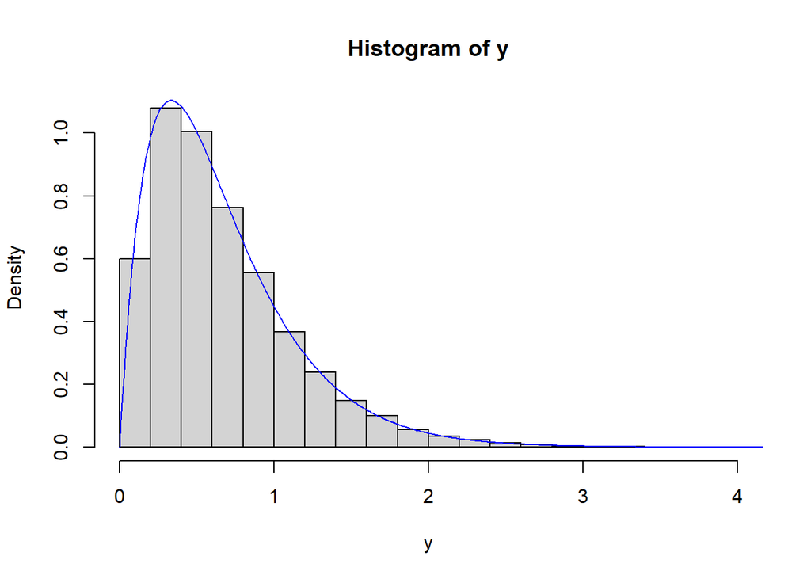

```r
> x1 <- rexp(50000, rate = 3)
> x2 <- rexp(50000, rate = 3)
> y <- x1 + x2
> mean(y)
[1] 0.6685355
> var(y)
[1] 0.2219982
> hist(y, probability = TRUE)
> xCoord <- seq(0, 5, 0.01)
> lines(xCoord,dgamma(xCoord, shape = 2, rate = 3), col = "blue")
```

При $n = 10$
$$Y = X_1 + ... + X_{10} \in \Gamma(10, 3)$$
$$f_Y(x) = \frac{10^2}{(10-1)!}x^{10-1}e^{-3x} = \frac{100}{9!}x^{9}e^{-3x} , \quad x > 0$$
$$E[X_1 + ... + X_{10}] = \frac{10}{3} \approx 3.33$$
$$D[X_1 + ... + X_{10}] = \frac{10}{3^2} \approx 1.11$$

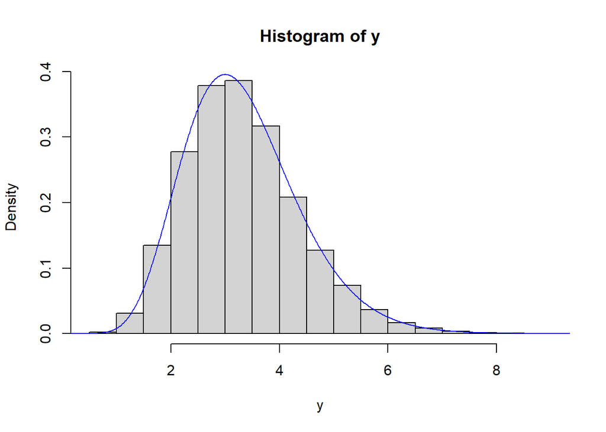

```r
> y <- rgamma(50000, shape = 10, rate = 3)
> mean(y)
[1] 3.331392
> var(y)
[1] 1.100908
> hist(y, probability = TRUE)
> xCoord <- seq(0, 15, 0.01)
> lines(xCoord,dgamma(xCoord, shape = 10, rate = 3), col = "blue")
```

При $n = 100$
$$Y = X_1 + ... + X_{100} \in \Gamma(100, 3)$$
$$f_Y(x) = \frac{100^2}{(100-1)!}x^{100-1}e^{-3x} = \frac{100}{9!}x^{9}e^{-3x} , \quad x > 0$$
$$E[X_1 + ... + X_{100}] = \frac{100}{3} \approx 33.33$$
$$D[X_1 + ... + X_{100}] = \frac{100}{3^2} \approx 11.11$$

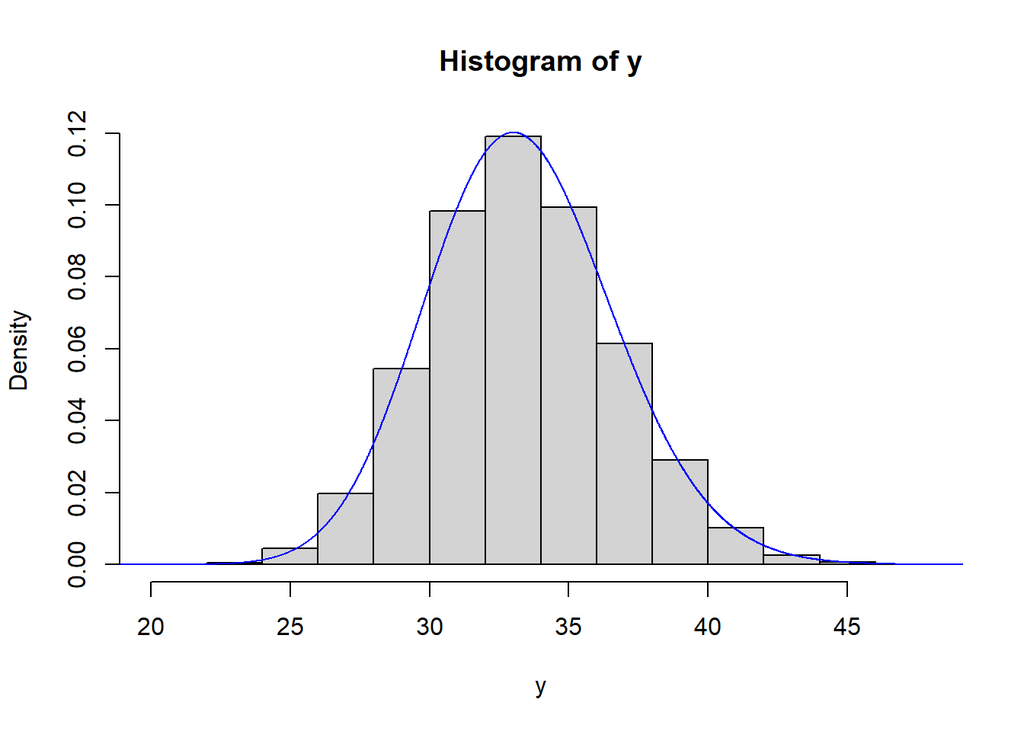

```r
> y <- rgamma(50000, shape = 100, rate = 3)
> mean(y)
[1] 33.3188
> var(y)
[1] 11.12722
> hist(y, probability = TRUE)
> xCoord <- seq(0, 50, 0.01)
> lines(xCoord, dgamma(xCoord, shape = 100, rate = 3), col = "blue")
```

т.к. $100$ е голямо можем да използваме централна гранична теорема (ЦГТ).

От централна гранична теорема (ЦГТ), ако $X_i$ еднакво разпределени, независими и с **крайна дисперсия** за $i = 1, ..., n$, то при увеличаване на обема на извадката
$$\frac{X_1 + X_2 + ... + X_n - n E[X]}{\sqrt{n D[X]}} \mathop{\to}^d N(0, 1)$$
В случая
$$E[X_i] = \frac{1}{3}$$
$$D[X_i] = \frac{1}{3^2}$$
$$Y = X_1 + X_2 + ... + X_n$$
$$\frac{Y - n \frac{1}{3}}{\sqrt{n \frac{1}{3^2}}} \mathop{\to}^d N(0, 1)$$

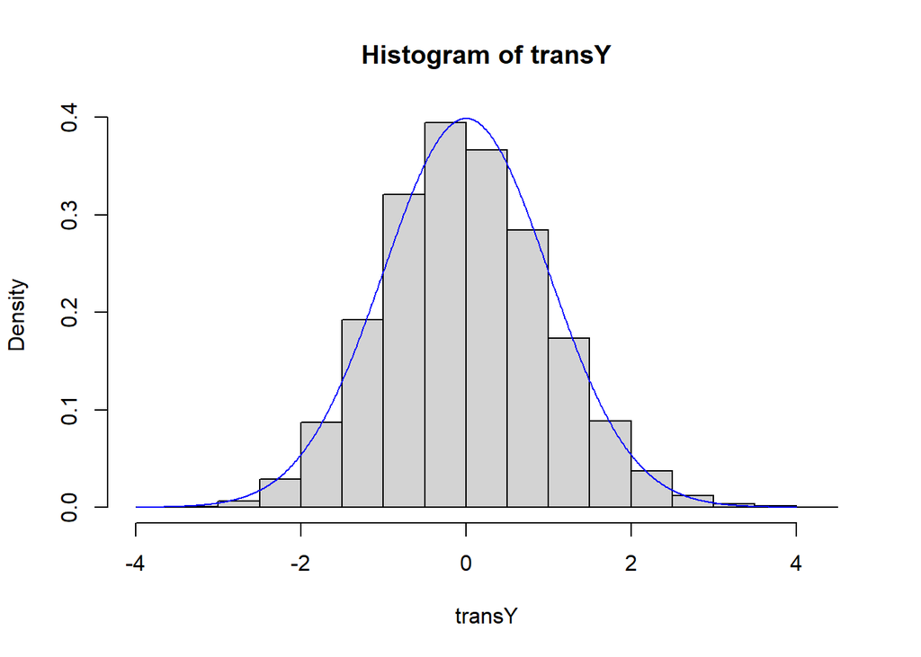

```r
> transY <- (y - n/3) / sqrt(n/9)
> hist(transY, probability = TRUE)
> xCoord <- seq(-4, 4, 0.01)
> lines(xCoord, dnorm(xCoord, 0, 1), col = "blue")
```

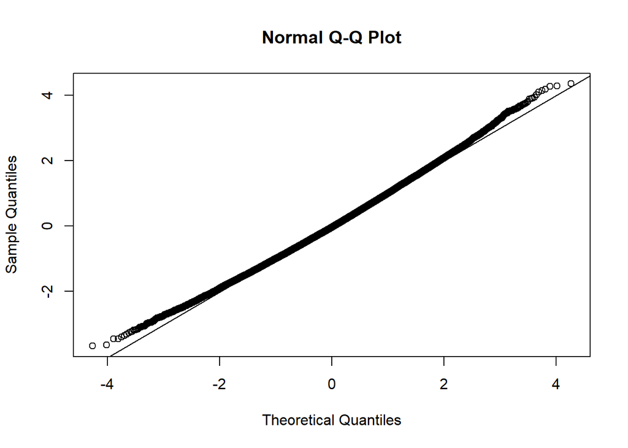

```r
> qqnorm(transY)
> qqline(transY)
```

г) $X_1, X_2, ..., X_n \in \Gamma(5, 1)$

Тъй като сума на независими гама случайни величини с един и същ втори параметър е отново гама със същия втори параметър, а първите параметри се сумират, то

$$Y = X_1 + X_2 + ... + X_n \in \Gamma(5n, 1)$$

$$f_Y(x) = \frac{1}{\Gamma(5n)}x^{5n-1}e^{-x} = \frac{1}{(5n-1)!}x^{5n-1}e^{-x}, \quad x > 0$$
$$E[X_1 + X_2 + \ldots + X_n] = 5n$$

$$D[X_1 + X_2 + \ldots + X_n] = 5n$$

При $n = 2$
$$Y = X_1 + X_2 \in \Gamma(10, 1)$$
$$f_Y(x) = \frac{1}{\Gamma(10)}x^{10-1}e^{-x} = \frac{1}{9!}x^9e^{-x}, \quad x > 0$$
$$E[X_1 + X_2] = 10$$
$$D[X_1 + X_2] = 10$$

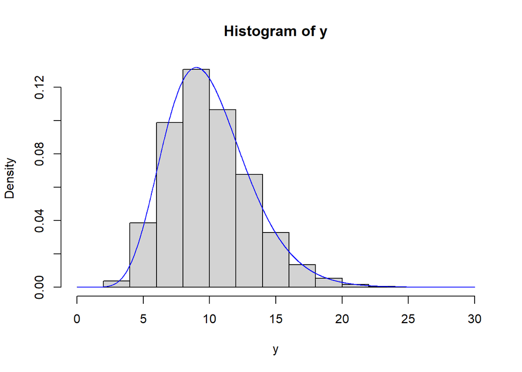

```r
> x1 <- rgamma(50000, shape = 5, rate = 1)
> x2 <- rgamma(50000, shape = 5, rate = 1)
> y <- x1 + x2
> mean(y)
[1] 10.00184
> var(y)
[1] 9.992787
> hist(y, probability = TRUE)
> xCoord <- seq(0, 30, 0.01)
> lines(xCoord,dgamma(xCoord, shape = 10, rate = 1), col = "blue")
```

При $n = 10$
$$Y = X_1 + ... + X_{10} \in \Gamma(50, 1)$$
$$f_Y(x) = \frac{1}{\Gamma(50)}x^{50-1}e^{-x} = \frac{1}{49!}x^{49}e^{-x}, \quad x > 0$$
$$E[X_1 + ... + X_{10}] = 50$$
$$D[X_1 + ... + X_{10}] = 50$$

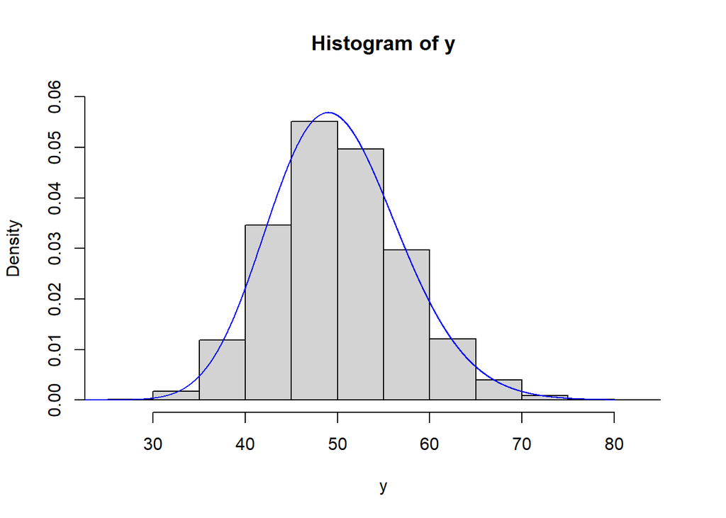

```r
> y <- rgamma(50000, shape = 50, rate = 1)
> mean(y)
[1] 50.06735
> var(y)
[1] 49.89873
> hist(y, probability = TRUE, ylim = c(0, 0.06))
> xCoord <- seq(0, 80, 0.01)
> lines(xCoord,dgamma(xCoord, shape = 50, rate = 1), col = "blue")
```

При $n = 100$
$$Y = X_1 + ... + X_{100} \in \Gamma(500, 1)$$
$$f_Y(x) = \frac{1}{\Gamma(500)}x^{500-1}e^{-x} = \frac{1}{499!}x^{499}e^{-x}, \quad x > 0$$
$$E[X_1 + ... + X_{100}] = 500$$
$$D[X_1 + ... + X_{100}] = 500$$

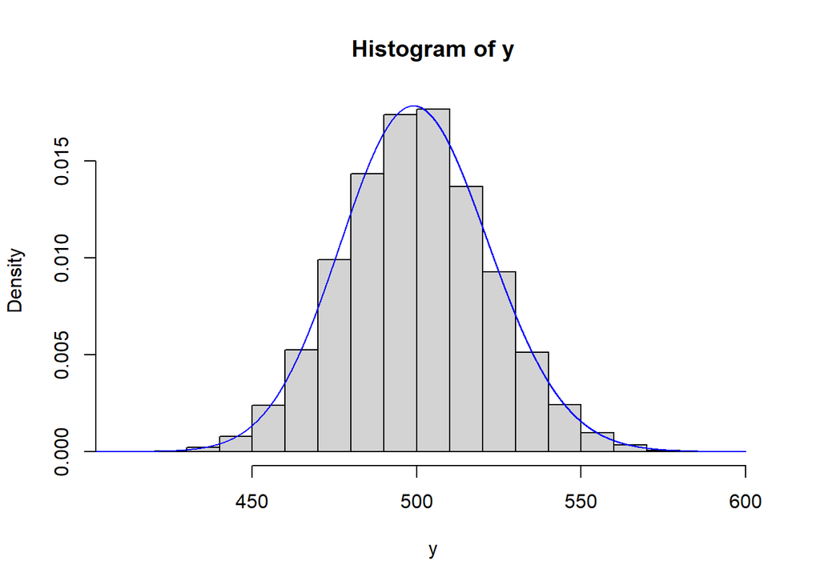

```r
> y <- rgamma(50000, shape = 500, rate = 1)
> mean(y)
[1] 499.9929
> var(y)
[1] 495.3741
> hist(y, probability = TRUE)
> xCoord <- seq(0, 600, 0.01)
> lines(xCoord, dgamma(xCoord, shape = 500, rate = 1), col = "blue")
```

т.к. $100$ е голямо можем да използваме централна гранична теорема (ЦГТ).

От централна гранична теорема (ЦГТ), ако $X_i$ еднакво разпределени, независими и с **крайна дисперсия** за $i = 1, ..., n$, то при увеличаване на обема на извадката
$$\frac{X_1 + X_2 + ... + X_n - n E[X]}{\sqrt{n D[X]}} \mathop{\to}^d N(0, 1)$$
В случая
$$E[X_i] = 5, \quad D[X_i] = 5$$
$$Y = X_1 + X_2 + ... + X_n$$
$$\frac{Y - 5n}{\sqrt{5n}} \mathop{\to}^d N(0, 1)$$

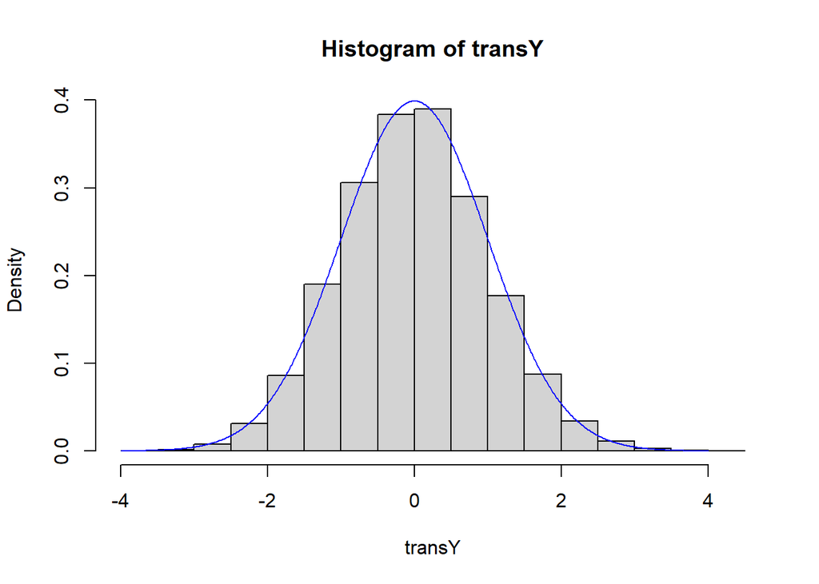

```r
> transY <- (y - 5*n) / sqrt(5*n)
> hist(transY, probability = TRUE)
> xCoord <- seq(-4, 4, 0.01)
> lines(xCoord, dnorm(xCoord, 0, 1), col = "blue")
```

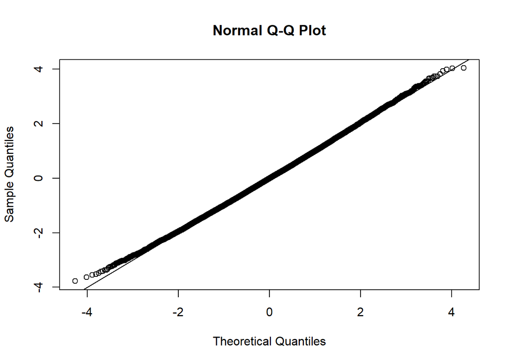

```r
> qqnorm(transY)
> qqline(transY)
```

д) $X_1, X_2, ..., X_n \in \chi^2(5)$

Тъй като $\chi^2(5) \equiv \Gamma(\frac{5}{2}, \frac{1}{2})$ и сума на независими гама случайни величини с един и същ втори параметър е отново гама със същия втори параметър, а първите параметри се сумират, то

$$Y = X_1 + X_2 + ... + X_n \in \Gamma(n \frac{5}{2}, \frac{1}{2})$$

$$f_Y(x) = \frac{\left(\frac{1}{2}\right)^{n\frac{5}{2}}}{\Gamma(\frac{5}{2}n)}x^{\frac{5}{2}n-1}e^{-\frac{x}{2}}, \quad x > 0$$
$$E[X_1 + X_2 + \ldots + X_n] = \frac{\frac{5}{2}n}{\frac{1}{2}} = 5n$$

$$D[X_1 + X_2 + \ldots + X_n] = \frac{\frac{5}{2}n}{\left(\frac{1}{2}\right)^2} = 10n$$